# NBA_model

# Data exploration & cleaning

```r
#Import dataset

NBA_Dataset <- read.csv("~/NBA_Dataset.csv")
print(NBA_Dataset[1:5,])
```

```
  season              player pos age team_id  g gs mp_per_g fg_per_g fga_per_g
1   1982 Kareem Abdul-Jabbar   C  34     LAL 76 76     35.2      9.9      17.1
2   1982         Alvan Adams   C  27     PHO 79 75     30.3      6.4      13.0
3   1982        Mark Aguirre  SF  22     DAL 51 20     28.8      7.5      16.1
4   1982         Danny Ainge  SG  22     BOS 53  1     10.6      1.5       4.2
5   1982      Tiny Archibald  PG  33     BOS 68 51     31.9      4.5       9.6
  fg_pct fg3_per_g fg3a_per_g fg3_pct fg2_per_g fg2a_per_g fg2_pct efg_pct
1  0.579       0.0        0.0   0.000       9.9       17.1   0.580   0.579
2  0.494       0.0        0.0   0.000       6.4       13.0   0.494   0.494
3  0.465       0.5        1.4   0.352       7.0       14.7   0.475   0.480
4  0.357       0.1        0.3   0.294       1.4        3.8   0.363   0.369
5  0.472       0.1        0.2   0.375       4.4        9.4   0.475   0.477
  ft_per_g fta_per_g ft_pct orb_per_g drb_per_g trb_per_g ast_per_g stl_per_g
1      4.1       5.8  0.706       2.3       6.4       8.7       3.0       0.8
2      2.3       2.9  0.781       1.7       5.7       7.4       4.5       1.4
```

[output cut: 27 more lines]

So there is a bunch of NA’s, so we explore the data preliminarilly

```r
str(NBA_Dataset)
```

```
'data.frame':   17697 obs. of  55 variables:
 $ season          : int  1982 1982 1982 1982 1982 1982 1982 1982 1982 1982 ...
 $ player          : chr  "Kareem Abdul-Jabbar" "Alvan Adams" "Mark Aguirre" "Danny Ainge" ...
 $ pos             : chr  "C" "C" "SF" "SG" ...
 $ age             : int  34 27 22 22 33 33 23 24 27 22 ...
 $ team_id         : chr  "LAL" "PHO" "DAL" "BOS" ...
 $ g               : int  76 79 51 53 68 10 1 77 79 80 ...
 $ gs              : int  76 75 20 1 51 3 0 0 79 4 ...
 $ mp_per_g        : num  35.2 30.3 28.8 10.6 31.9 12.1 7 19.1 37.3 21.3 ...
 $ fg_per_g        : num  9.9 6.4 7.5 1.5 4.5 0.5 1 3.4 7.9 3.9 ...
 $ fga_per_g       : num  17.1 13 16.1 4.2 9.6 1.5 1 6.6 16.5 8.2 ...
 $ fg_pct          : num  0.579 0.494 0.465 0.357 0.472 0.333 1 0.517 0.475 0.477 ...
 $ fg3_per_g       : num  0 0 0.5 0.1 0.1 0 0 0 0.1 0 ...
 $ fg3a_per_g      : num  0 0 1.4 0.3 0.2 0 0 0 0.3 0.1 ...
 $ fg3_pct         : num  0 0 0.352 0.294 0.375 NA NA NA 0.409 0 ...
```

[output cut: 41 more lines]

```r
skim(NBA_Dataset)
```

Data summary

| Name | NBA_Dataset |
| --- | --- |
| Number of rows | 17697 |
| Number of columns | 55 |
| _______________________ |  |
| Column type frequency: |  |
| character | 3 |
| numeric | 52 |
| ________________________ |  |
| Group variables | None |

**Variable type: character**

| skim_variable | n_missing | complete_rate | min | max | empty | n_unique | whitespace |
| --- | --- | --- | --- | --- | --- | --- | --- |
| player | 0 | 1 | 4 | 24 | 0 | 3283 | 0 |
| pos | 0 | 1 | 1 | 8 | 0 | 17 | 0 |
| team_id | 0 | 1 | 3 | 3 | 0 | 41 | 0 |

**Variable type: numeric**

| skim_variable | n_missing | complete_rate | mean | sd | p0 | p25 | p50 | p75 | p100 | hist |
| --- | --- | --- | --- | --- | --- | --- | --- | --- | --- | --- |
| season | 0 | 1.00 | 2003.79 | 11.66 | 1982.00 | 1994.00 | 2004.00 | 2014.00 | 2022.00 | ▆▆▇▇▇ |
| age | 0 | 1.00 | 26.65 | 4.11 | 18.00 | 23.00 | 26.00 | 29.00 | 44.00 | ▅▇▅▁▁ |
| g | 0 | 1.00 | 53.48 | 25.29 | 1.00 | 34.00 | 61.00 | 76.00 | 85.00 | ▃▂▃▅▇ |
| gs | 0 | 1.00 | 26.04 | 29.39 | 0.00 | 1.00 | 11.00 | 52.00 | 83.00 | ▇▂▁▂▂ |
| mp_per_g | 0 | 1.00 | 20.41 | 10.11 | 0.00 | 12.00 | 19.80 | 28.90 | 43.70 | ▅▇▇▆▂ |
| fg_per_g | 0 | 1.00 | 3.18 | 2.27 | 0.00 | 1.40 | 2.60 | 4.50 | 13.40 | ▇▅▂▁▁ |
| fga_per_g | 0 | 1.00 | 6.99 | 4.71 | 0.00 | 3.30 | 5.90 | 9.80 | 27.80 | ▇▆▂▁▁ |
| fg_pct | 63 | 1.00 | 0.44 | 0.09 | 0.00 | 0.41 | 0.45 | 0.49 | 1.00 | ▁▂▇▁▁ |
| fg3_per_g | 0 | 1.00 | 0.48 | 0.66 | 0.00 | 0.00 | 0.10 | 0.80 | 5.30 | ▇▂▁▁▁ |
| fg3a_per_g | 0 | 1.00 | 1.38 | 1.74 | 0.00 | 0.00 | 0.60 | 2.30 | 13.20 | ▇▂▁▁▁ |
| fg3_pct | 2623 | 0.85 | 0.26 | 0.17 | 0.00 | 0.15 | 0.31 | 0.37 | 1.00 | ▅▇▂▁▁ |
| fg2_per_g | 0 | 1.00 | 2.70 | 2.10 | 0.00 | 1.10 | 2.10 | 3.80 | 13.20 | ▇▃▂▁▁ |
| fg2a_per_g | 0 | 1.00 | 5.61 | 4.12 | 0.00 | 2.40 | 4.50 | 7.90 | 27.00 | ▇▃▂▁▁ |
| fg2_pct | 106 | 0.99 | 0.47 | 0.10 | 0.00 | 0.43 | 0.47 | 0.51 | 1.00 | ▁▁▇▁▁ |
| efg_pct | 63 | 1.00 | 0.47 | 0.10 | 0.00 | 0.44 | 0.48 | 0.52 | 1.50 | ▁▇▁▁▁ |
| ft_per_g | 0 | 1.00 | 1.57 | 1.43 | 0.00 | 0.60 | 1.10 | 2.10 | 10.30 | ▇▂▁▁▁ |
| fta_per_g | 0 | 1.00 | 2.10 | 1.80 | 0.00 | 0.80 | 1.60 | 2.90 | 13.10 | ▇▂▁▁▁ |
| ft_pct | 576 | 0.97 | 0.73 | 0.14 | 0.00 | 0.67 | 0.75 | 0.81 | 1.00 | ▁▁▂▇▅ |
| orb_per_g | 0 | 1.00 | 1.03 | 0.86 | 0.00 | 0.40 | 0.80 | 1.40 | 6.90 | ▇▂▁▁▁ |
| drb_per_g | 0 | 1.00 | 2.57 | 1.82 | 0.00 | 1.20 | 2.20 | 3.40 | 12.30 | ▇▅▁▁▁ |
| trb_per_g | 0 | 1.00 | 3.60 | 2.55 | 0.00 | 1.70 | 3.00 | 4.80 | 18.70 | ▇▃▁▁▁ |
| ast_per_g | 0 | 1.00 | 1.91 | 1.88 | 0.00 | 0.60 | 1.30 | 2.60 | 14.50 | ▇▂▁▁▁ |
| stl_per_g | 0 | 1.00 | 0.67 | 0.47 | 0.00 | 0.30 | 0.60 | 0.90 | 3.70 | ▇▃▁▁▁ |
| blk_per_g | 0 | 1.00 | 0.42 | 0.50 | 0.00 | 0.10 | 0.30 | 0.50 | 5.60 | ▇▁▁▁▁ |
| tov_per_g | 0 | 1.00 | 1.25 | 0.82 | 0.00 | 0.60 | 1.10 | 1.70 | 5.70 | ▇▅▂▁▁ |
| pf_per_g | 0 | 1.00 | 1.92 | 0.85 | 0.00 | 1.30 | 1.90 | 2.50 | 6.00 | ▃▇▅▁▁ |
| pts_per_g | 0 | 1.00 | 8.42 | 6.10 | 0.00 | 3.70 | 6.90 | 11.90 | 37.10 | ▇▅▂▁▁ |
| mp | 0 | 1.00 | 1258.83 | 915.35 | 0.00 | 406.00 | 1176.00 | 2000.00 | 3533.00 | ▇▅▅▃▁ |
| per | 3 | 1.00 | 12.78 | 6.15 | -90.60 | 9.90 | 12.90 | 15.90 | 133.80 | ▁▁▇▁▁ |
| ts_pct | 55 | 1.00 | 0.51 | 0.09 | 0.00 | 0.48 | 0.52 | 0.56 | 1.50 | ▁▇▁▁▁ |
| fg3a_per_fga_pct | 63 | 1.00 | 0.19 | 0.21 | 0.00 | 0.01 | 0.12 | 0.35 | 1.00 | ▇▃▂▁▁ |
| fta_per_fga_pct | 63 | 1.00 | 0.31 | 0.22 | 0.00 | 0.19 | 0.28 | 0.38 | 6.00 | ▇▁▁▁▁ |
| orb_pct | 3 | 1.00 | 6.01 | 4.87 | 0.00 | 2.40 | 5.00 | 8.80 | 100.00 | ▇▁▁▁▁ |
| drb_pct | 3 | 1.00 | 14.07 | 6.51 | 0.00 | 9.30 | 13.10 | 18.20 | 100.00 | ▇▂▁▁▁ |
| trb_pct | 3 | 1.00 | 10.04 | 4.97 | 0.00 | 6.20 | 9.20 | 13.40 | 86.40 | ▇▁▁▁▁ |
| ast_pct | 3 | 1.00 | 13.14 | 9.47 | 0.00 | 6.50 | 10.30 | 17.80 | 100.00 | ▇▂▁▁▁ |
| stl_pct | 3 | 1.00 | 1.63 | 1.01 | 0.00 | 1.10 | 1.50 | 2.00 | 25.00 | ▇▁▁▁▁ |
| blk_pct | 3 | 1.00 | 1.53 | 1.76 | 0.00 | 0.40 | 1.00 | 2.10 | 77.80 | ▇▁▁▁▁ |
| tov_pct | 46 | 1.00 | 14.43 | 6.28 | 0.00 | 11.00 | 13.70 | 17.00 | 100.00 | ▇▁▁▁▁ |
| usg_pct | 3 | 1.00 | 18.86 | 5.46 | 0.00 | 15.30 | 18.50 | 22.10 | 100.00 | ▇▅▁▁▁ |
| ows | 0 | 1.00 | 1.37 | 2.10 | -3.30 | 0.00 | 0.60 | 2.20 | 15.20 | ▇▇▂▁▁ |
| dws | 0 | 1.00 | 1.29 | 1.22 | -1.00 | 0.30 | 1.00 | 1.90 | 9.10 | ▇▆▁▁▁ |
| ws | 0 | 1.00 | 2.66 | 3.02 | -2.10 | 0.30 | 1.70 | 4.10 | 21.20 | ▇▅▁▁▁ |
| ws_per_48 | 3 | 1.00 | 0.07 | 0.10 | -2.52 | 0.04 | 0.08 | 0.12 | 2.71 | ▁▁▇▁▁ |
| obpm | 0 | 1.00 | -1.49 | 3.99 | -68.90 | -3.20 | -1.30 | 0.40 | 199.40 | ▁▇▁▁▁ |
| dbpm | 0 | 1.00 | -0.19 | 1.80 | -31.10 | -1.00 | -0.20 | 0.70 | 60.70 | ▁▇▁▁▁ |
| bpm | 0 | 1.00 | -1.68 | 4.96 | -92.10 | -3.50 | -1.40 | 0.50 | 242.20 | ▁▇▁▁▁ |
| vorp | 0 | 1.00 | 0.64 | 1.37 | -2.60 | -0.10 | 0.10 | 1.00 | 12.50 | ▇▅▁▁▁ |
| award_share | 0 | 1.00 | 0.01 | 0.06 | 0.00 | 0.00 | 0.00 | 0.00 | 1.00 | ▇▁▁▁▁ |
| mov | 0 | 1.00 | 0.00 | 4.41 | -15.20 | -2.82 | 0.00 | 3.02 | 12.24 | ▁▃▇▆▁ |
| mov_adj | 0 | 1.00 | 0.00 | 4.26 | -14.68 | -2.62 | 0.00 | 2.84 | 11.80 | ▁▃▇▆▁ |
| win_loss_pct | 0 | 1.00 | 0.50 | 0.15 | 0.11 | 0.40 | 0.50 | 0.61 | 0.89 | ▁▃▇▅▁ |

There are columns with missing data, which can be separated into two categories:

1. Percentages where the denominator is zero - players didn’t attempt that type of shot, so calculating a percentage would result in an error (undefined) -> fixed by replacing the NA’s with zero
2. PER of zero - which we’ll investigate now

```r
NBA_Dataset %>% filter(is.na(per))
```

```
  season        player pos age team_id g gs mp_per_g fg_per_g fga_per_g fg_pct
1   2006   Alex Scales  SG  27     SAS 1  0        0        0         0     NA
2   2010 JamesOn Curry  PG  24     LAC 1  0        0        0         0     NA
3   2013  Damion James  SF  25     BRK 2  0        0        0         0     NA
  fg3_per_g fg3a_per_g fg3_pct fg2_per_g fg2a_per_g fg2_pct efg_pct ft_per_g
1         0          0      NA         0          0      NA      NA        0
2         0          0      NA         0          0      NA      NA        0
3         0          0      NA         0          0      NA      NA        0
  fta_per_g ft_pct orb_per_g drb_per_g trb_per_g ast_per_g stl_per_g blk_per_g
1         0     NA         0       0.0       0.0         0         0         0
2         0     NA         0       0.0       0.0         0         0         0
3         0     NA         0       0.5       0.5         0         0         0
  tov_per_g pf_per_g pts_per_g mp per ts_pct fg3a_per_fga_pct fta_per_fga_pct
1         0        0         0  0  NA     NA               NA              NA
2         0        0         0  0  NA     NA               NA              NA
3         0        0         0  0  NA     NA               NA              NA
  orb_pct drb_pct trb_pct ast_pct stl_pct blk_pct tov_pct usg_pct ows dws ws
1      NA      NA      NA      NA      NA      NA      NA      NA   0   0  0
2      NA      NA      NA      NA      NA      NA      NA      NA   0   0  0
3      NA      NA      NA      NA      NA      NA      NA      NA   0   0  0
  ws_per_48 obpm dbpm  bpm vorp award_share   mov mov_adj win_loss_pct
1        NA -5.0 -0.7 -5.7    0           0  6.82    6.69        0.768
2        NA -6.4 -0.6 -7.0    0           0 -6.35   -6.01        0.354
3        NA -3.8 17.8 14.0    0           0  1.78    1.25        0.598
```

It is found that the NA’s for the PER are the result of players that played less then half a minute, so their minutes played was rounded to zero, which then made the PER undefined. Players with zero minutes were excluded from the dataset initially, so we just do that.

```r
#Fixing the NA's

## To remove the na's for per
NBA_Dataset <- NBA_Dataset %>% filter(!is.na(NBA_Dataset$per))

## To remove the na's for the pct's
NBA_Dataset[is.na(NBA_Dataset)]=0

skim(NBA_Dataset)
```

Data summary

| Name | NBA_Dataset |
| --- | --- |
| Number of rows | 17694 |
| Number of columns | 55 |
| _______________________ |  |
| Column type frequency: |  |
| character | 3 |
| numeric | 52 |
| ________________________ |  |
| Group variables | None |

**Variable type: character**

| skim_variable | n_missing | complete_rate | min | max | empty | n_unique | whitespace |
| --- | --- | --- | --- | --- | --- | --- | --- |
| player | 0 | 1 | 4 | 24 | 0 | 3281 | 0 |
| pos | 0 | 1 | 1 | 8 | 0 | 17 | 0 |
| team_id | 0 | 1 | 3 | 3 | 0 | 41 | 0 |

**Variable type: numeric**

| skim_variable | n_missing | complete_rate | mean | sd | p0 | p25 | p50 | p75 | p100 | hist |
| --- | --- | --- | --- | --- | --- | --- | --- | --- | --- | --- |
| season | 0 | 1 | 2003.78 | 11.66 | 1982.00 | 1994.00 | 2004.00 | 2014.00 | 2022.00 | ▆▆▇▇▇ |
| age | 0 | 1 | 26.65 | 4.11 | 18.00 | 23.00 | 26.00 | 29.00 | 44.00 | ▅▇▅▁▁ |
| g | 0 | 1 | 53.49 | 25.29 | 1.00 | 34.00 | 61.00 | 76.00 | 85.00 | ▃▂▃▅▇ |
| gs | 0 | 1 | 26.04 | 29.39 | 0.00 | 1.00 | 11.00 | 52.00 | 83.00 | ▇▂▁▂▂ |
| mp_per_g | 0 | 1 | 20.41 | 10.11 | 0.70 | 12.00 | 19.80 | 28.90 | 43.70 | ▅▇▇▆▂ |
| fg_per_g | 0 | 1 | 3.18 | 2.27 | 0.00 | 1.40 | 2.60 | 4.50 | 13.40 | ▇▅▂▁▁ |
| fga_per_g | 0 | 1 | 6.99 | 4.71 | 0.00 | 3.30 | 5.90 | 9.80 | 27.80 | ▇▆▂▁▁ |
| fg_pct | 0 | 1 | 0.44 | 0.10 | 0.00 | 0.40 | 0.44 | 0.49 | 1.00 | ▁▂▇▁▁ |
| fg3_per_g | 0 | 1 | 0.48 | 0.66 | 0.00 | 0.00 | 0.10 | 0.80 | 5.30 | ▇▂▁▁▁ |
| fg3a_per_g | 0 | 1 | 1.38 | 1.74 | 0.00 | 0.00 | 0.60 | 2.30 | 13.20 | ▇▂▁▁▁ |
| fg3_pct | 0 | 1 | 0.22 | 0.18 | 0.00 | 0.00 | 0.27 | 0.36 | 1.00 | ▇▇▂▁▁ |
| fg2_per_g | 0 | 1 | 2.70 | 2.10 | 0.00 | 1.10 | 2.10 | 3.80 | 13.20 | ▇▃▂▁▁ |
| fg2a_per_g | 0 | 1 | 5.61 | 4.12 | 0.00 | 2.50 | 4.50 | 7.90 | 27.00 | ▇▃▂▁▁ |
| fg2_pct | 0 | 1 | 0.47 | 0.10 | 0.00 | 0.43 | 0.47 | 0.51 | 1.00 | ▁▁▇▁▁ |
| efg_pct | 0 | 1 | 0.47 | 0.10 | 0.00 | 0.44 | 0.48 | 0.52 | 1.50 | ▁▇▁▁▁ |
| ft_per_g | 0 | 1 | 1.57 | 1.43 | 0.00 | 0.60 | 1.10 | 2.10 | 10.30 | ▇▂▁▁▁ |
| fta_per_g | 0 | 1 | 2.10 | 1.80 | 0.00 | 0.80 | 1.60 | 2.90 | 13.10 | ▇▂▁▁▁ |
| ft_pct | 0 | 1 | 0.70 | 0.19 | 0.00 | 0.65 | 0.75 | 0.81 | 1.00 | ▁▁▂▇▅ |
| orb_per_g | 0 | 1 | 1.03 | 0.86 | 0.00 | 0.40 | 0.80 | 1.40 | 6.90 | ▇▂▁▁▁ |
| drb_per_g | 0 | 1 | 2.57 | 1.82 | 0.00 | 1.20 | 2.20 | 3.40 | 12.30 | ▇▅▁▁▁ |
| trb_per_g | 0 | 1 | 3.60 | 2.55 | 0.00 | 1.70 | 3.00 | 4.80 | 18.70 | ▇▃▁▁▁ |
| ast_per_g | 0 | 1 | 1.91 | 1.88 | 0.00 | 0.60 | 1.30 | 2.60 | 14.50 | ▇▂▁▁▁ |
| stl_per_g | 0 | 1 | 0.67 | 0.47 | 0.00 | 0.30 | 0.60 | 0.90 | 3.70 | ▇▃▁▁▁ |
| blk_per_g | 0 | 1 | 0.42 | 0.50 | 0.00 | 0.10 | 0.30 | 0.50 | 5.60 | ▇▁▁▁▁ |
| tov_per_g | 0 | 1 | 1.25 | 0.82 | 0.00 | 0.60 | 1.10 | 1.70 | 5.70 | ▇▅▂▁▁ |
| pf_per_g | 0 | 1 | 1.93 | 0.85 | 0.00 | 1.30 | 1.90 | 2.50 | 6.00 | ▃▇▅▁▁ |
| pts_per_g | 0 | 1 | 8.42 | 6.10 | 0.00 | 3.70 | 6.90 | 11.90 | 37.10 | ▇▅▂▁▁ |
| mp | 0 | 1 | 1259.05 | 915.28 | 1.00 | 406.25 | 1177.00 | 2000.75 | 3533.00 | ▇▅▅▃▁ |
| per | 0 | 1 | 12.78 | 6.15 | -90.60 | 9.90 | 12.90 | 15.90 | 133.80 | ▁▁▇▁▁ |
| ts_pct | 0 | 1 | 0.51 | 0.10 | 0.00 | 0.48 | 0.52 | 0.56 | 1.50 | ▁▇▁▁▁ |
| fg3a_per_fga_pct | 0 | 1 | 0.19 | 0.21 | 0.00 | 0.01 | 0.12 | 0.34 | 1.00 | ▇▃▂▁▁ |
| fta_per_fga_pct | 0 | 1 | 0.31 | 0.22 | 0.00 | 0.19 | 0.28 | 0.38 | 6.00 | ▇▁▁▁▁ |
| orb_pct | 0 | 1 | 6.01 | 4.87 | 0.00 | 2.40 | 5.00 | 8.80 | 100.00 | ▇▁▁▁▁ |
| drb_pct | 0 | 1 | 14.07 | 6.51 | 0.00 | 9.30 | 13.10 | 18.20 | 100.00 | ▇▂▁▁▁ |
| trb_pct | 0 | 1 | 10.04 | 4.97 | 0.00 | 6.20 | 9.20 | 13.40 | 86.40 | ▇▁▁▁▁ |
| ast_pct | 0 | 1 | 13.14 | 9.47 | 0.00 | 6.50 | 10.30 | 17.80 | 100.00 | ▇▂▁▁▁ |
| stl_pct | 0 | 1 | 1.63 | 1.01 | 0.00 | 1.10 | 1.50 | 2.00 | 25.00 | ▇▁▁▁▁ |
| blk_pct | 0 | 1 | 1.53 | 1.76 | 0.00 | 0.40 | 1.00 | 2.10 | 77.80 | ▇▁▁▁▁ |
| tov_pct | 0 | 1 | 14.40 | 6.31 | 0.00 | 10.90 | 13.70 | 17.00 | 100.00 | ▇▁▁▁▁ |
| usg_pct | 0 | 1 | 18.86 | 5.46 | 0.00 | 15.30 | 18.50 | 22.10 | 100.00 | ▇▅▁▁▁ |
| ows | 0 | 1 | 1.37 | 2.10 | -3.30 | 0.00 | 0.60 | 2.20 | 15.20 | ▇▇▂▁▁ |
| dws | 0 | 1 | 1.29 | 1.22 | -1.00 | 0.30 | 1.00 | 1.90 | 9.10 | ▇▆▁▁▁ |
| ws | 0 | 1 | 2.66 | 3.02 | -2.10 | 0.30 | 1.70 | 4.10 | 21.20 | ▇▅▁▁▁ |
| ws_per_48 | 0 | 1 | 0.07 | 0.10 | -2.52 | 0.04 | 0.08 | 0.12 | 2.71 | ▁▁▇▁▁ |
| obpm | 0 | 1 | -1.49 | 3.99 | -68.90 | -3.20 | -1.30 | 0.40 | 199.40 | ▁▇▁▁▁ |
| dbpm | 0 | 1 | -0.19 | 1.79 | -31.10 | -1.00 | -0.20 | 0.70 | 60.70 | ▁▇▁▁▁ |
| bpm | 0 | 1 | -1.68 | 4.96 | -92.10 | -3.50 | -1.40 | 0.50 | 242.20 | ▁▇▁▁▁ |
| vorp | 0 | 1 | 0.64 | 1.37 | -2.60 | -0.10 | 0.10 | 1.00 | 12.50 | ▇▅▁▁▁ |
| award_share | 0 | 1 | 0.01 | 0.06 | 0.00 | 0.00 | 0.00 | 0.00 | 1.00 | ▇▁▁▁▁ |
| mov | 0 | 1 | 0.00 | 4.41 | -15.20 | -2.82 | 0.00 | 3.02 | 12.24 | ▁▃▇▆▁ |
| mov_adj | 0 | 1 | 0.00 | 4.26 | -14.68 | -2.62 | 0.00 | 2.84 | 11.80 | ▁▃▇▆▁ |
| win_loss_pct | 0 | 1 | 0.50 | 0.15 | 0.11 | 0.40 | 0.50 | 0.61 | 0.89 | ▁▃▇▅▁ |

Incompleteness issues now fixed. Removed 3 records, so 17 694 remain. Dataset has 55 columns, of which 3 are categorical (player, pos, team_id) and the rest are numerical.

Regarding the categorical variables, the name is removed from the analysis (player name doesn’t matter), while the positions and team variables are converted to individual binary variables for each position and team.

```r
# Conversion of pos & team_id to factors

NBA_Dataset$pos <- as.factor(NBA_Dataset$pos)
NBA_Dataset$team_id <- as.factor(NBA_Dataset$team_id)

levels(NBA_Dataset$team_id)
```

```
 [1] "ATL" "BOS" "BRK" "CHA" "CHH" "CHI" "CHO" "CLE" "DAL" "DEN" "DET" "GSW"
[13] "HOU" "IND" "KCK" "LAC" "LAL" "MEM" "MIA" "MIL" "MIN" "NJN" "NOH" "NOK"
[25] "NOP" "NYK" "OKC" "ORL" "PHI" "PHO" "POR" "SAC" "SAS" "SDC" "SEA" "TOR"
[37] "TOT" "UTA" "VAN" "WAS" "WSB"
```

```r
levels(NBA_Dataset$pos)
```

```
 [1] "C"        "C-PF"     "PF"       "PF-C"     "PF-SF"    "PG"
 [7] "PG-SF"    "PG-SG"    "SF"       "SF-C"     "SF-PF"    "SF-SG"
[13] "SG"       "SG-PF"    "SG-PG"    "SG-PG-SF" "SG-SF"
```

Despite there being only 30 teams in the nba, the dataset has 41 teams. To allow for the 1-for-1 comparison, the older teams are replaced by either their new rebranded version, or replaced by the most similar, be it by location, shared history,etc.

```r
#fixing team names

NBA_Dataset$team_id <- recode(NBA_Dataset$team_id,
  "CHH" = "CHA",
  "CHO" = "CHA",
  "KCK" = "SAC",
  "NJN" = "BRK",
  "NOH" = "NOP",
  "NOK" = "NOP",
  "SDC" = "LAC",
  "SEA" = "OKC",
  "TOT" = "CLE",
  "VAN" = "MEM",
  "WSB" = "WAS"
)


NBA_Dataset$team_id <- recode(NBA_Dataset$team_id,
  "1"  = "ATL",
  "9"  = "DAL",
  "10" = "DEN",
  "11" = "DET",
  "12" = "GSW",
  "13" = "HOU",
  "14" = "IND",
  "16" = "LAC",
  "17" = "LAL",
  "18" = "MEM",
  "19" = "MIA",
  "2"  = "BOS",
  "20" = "MIL",
  "21" = "MIN",
  "25" = "NOP",
  "26" = "NYK",
  "27" = "OKC",
  "28" = "NOP",
  "29" = "PHI",
  "3"  = "BRK",
  "30" = "PHO",
  "31" = "PHO",
  "32" = "SAC",
  "33" = "SAS",
  "36" = "TOR",
  "38" = "UTA",
  "40" = "WAS",
  "6"  = "CHI",
  "8"  = "CLE",
  "4"  = "CHA"
)

NBA_Dataset$team_id <- as.factor(NBA_Dataset$team_id)

levels(NBA_Dataset$team_id)
```

```
 [1] "ATL" "BOS" "BRK" "CHA" "CHI" "CLE" "DAL" "DEN" "DET" "GSW" "HOU" "IND"
[13] "SAC" "LAC" "LAL" "MEM" "MIA" "MIL" "MIN" "NOP" "NYK" "OKC" "ORL" "PHI"
[25] "PHO" "POR" "SAS" "TOR" "UTA" "WAS"
```

Changes are as follows:

- CHH,CHO -> CHA
- KCK -> SAC
- NJN -> BRK
- NOH,NOK -> NOP
- SDC -> LAC
- SEA -> OKC
- TOT -> CLE
- VAN -> MEM
- WSB -> WAS

Now only the 30 current teams remain.

```r
table(NBA_Dataset$pos)
```

```
       C     C-PF       PF     PF-C    PF-SF       PG    PG-SF    PG-SG
    3579       31     3633       31       31     3371        1       33
      SF     SF-C    SF-PF    SF-SG       SG    SG-PF    SG-PG SG-PG-SF
    3291        1       24       39     3561        4       31        1
   SG-SF
      32
```

There are multiple counts of only 1-5, which will be problematic for modelling. Therefore these values are simplified to only list the 5 primary positions (the first one where there is an aggregation).

```r
NBA_Dataset$pos <- recode(NBA_Dataset$pos,
                          "C-PF" = "C",
                          "PF-C" = "PF",
                          "PF-SF" = "PF",
                          "PG-SF" = "PG",
                          "PG-SG" = "PG",
                          "SF-C" = "SF",
                          "SF-PF" = "SF",
                          "SF-SG" = "SF",
                          "SG-PF" = "SG",
                          "SG-PG" = "SG",
                          "SG-PG-SF" = "SG",
                          "SG-SF" = "SG")

NBA_Dataset$pos <- as.factor(NBA_Dataset$pos)

levels(NBA_Dataset$pos)
```

```
[1] "C"  "PF" "PG" "SF" "SG"
```

This concludes all the preliminary data exploration and cleaning

The final step is to one-hot encode all the categorical variables:

```r
encoded_team_id <- model.matrix( ~ team_id - 1, NBA_Dataset)
colnames(encoded_team_id) <- c("ATL", "BOS", "BRK", "CHA", "CHI", "CLE", "DAL", "DEN", "DET", "GSW", "HOU", "IND", "SAC", "LAC", "LAL", "MEM", "MIA", "MIL", "MIN", "NOP", "NYK", "OKC", "ORL", "PHI", "PHO", "POR", "SAS", "TOR", "UTA", "WAS")

encoded_pos <- model.matrix( ~ pos - 1, NBA_Dataset)
colnames(encoded_pos) <- c("C","PF","PG","SF","SG")

NBA_Dataset <- cbind(NBA_Dataset,encoded_pos,encoded_team_id)

#To remove player names (not needed), position (encoded) and team id (encoded)
Data <- NBA_Dataset[,-c(2,3,5)]
```

# EDA

## Correlations

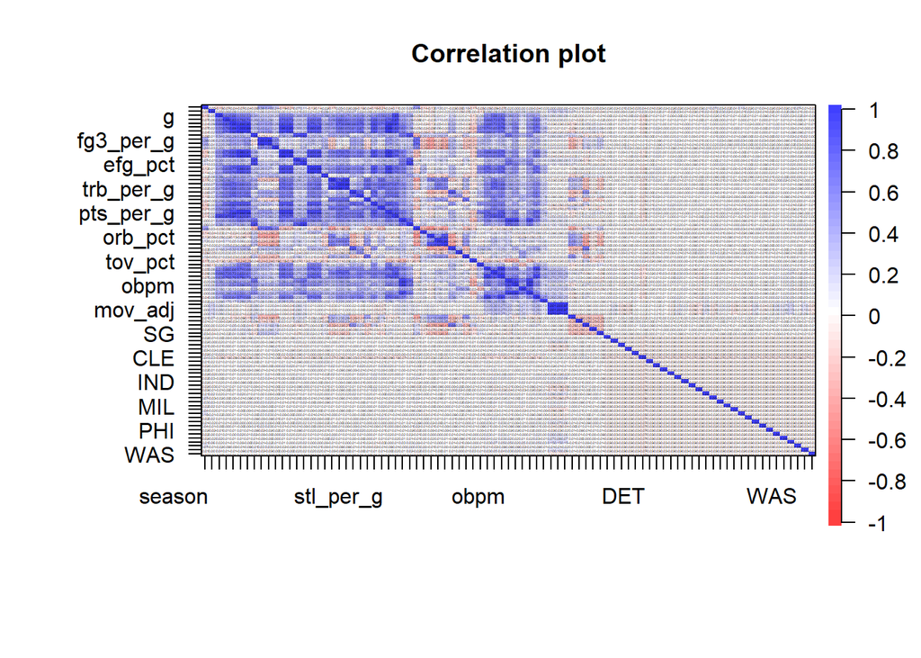

```r
#Correlations
cor_data <- cor(Data)
cor.plot(cor_data, colors = TRUE)
```

There are correlations throughout for the volume related variable (2pt attempts and minutes/games played).

## PCA

```
In smc, smcs < 0 were set to .0
In smc, smcs < 0 were set to .0
In smc, smcs < 0 were set to .0
```

```
In factor.scores, the correlation matrix is singular, the pseudo inverse is  used
```

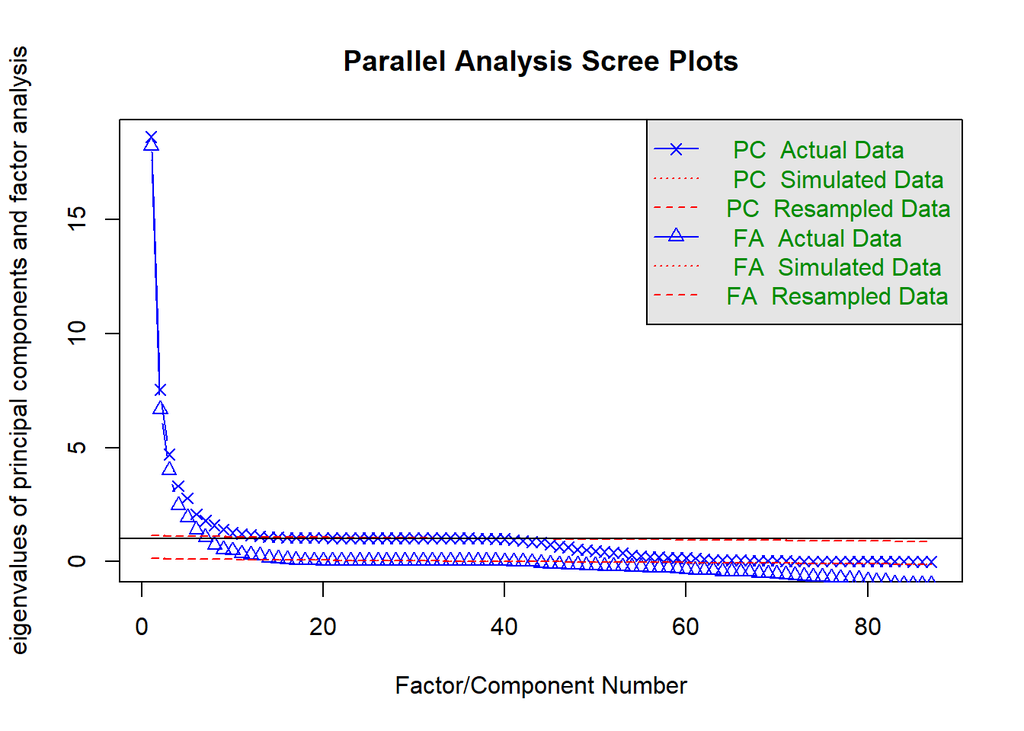

```
Parallel analysis suggests that the number of factors =  16  and the number of components =  14
```

```r
##Scree plot
fa.parallel(Data)
```

This suggests 14 components

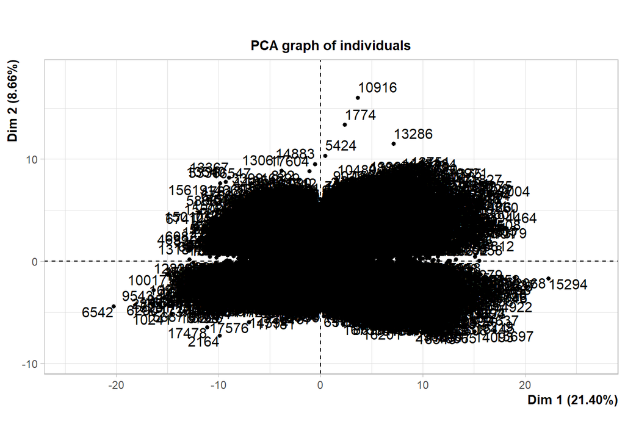

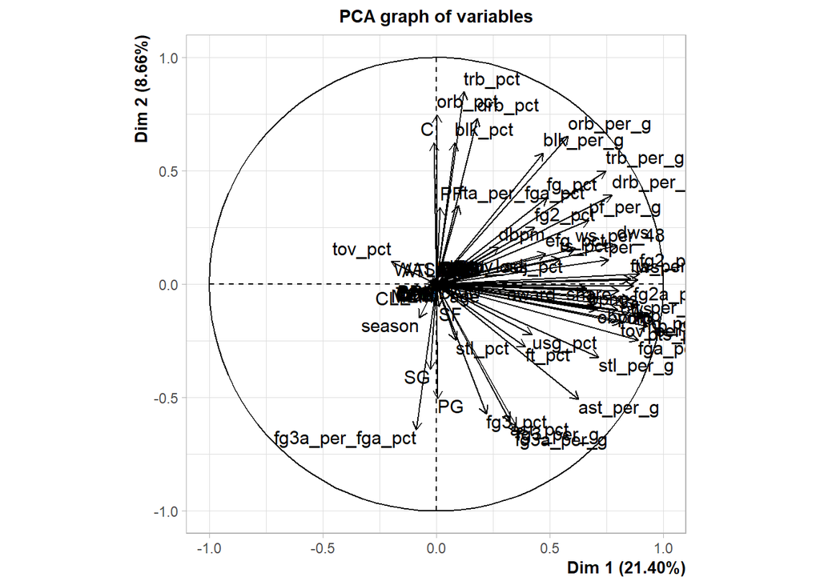

```r
#PCA
PCA_nba <- PCA(Data, ncp = 14)
```

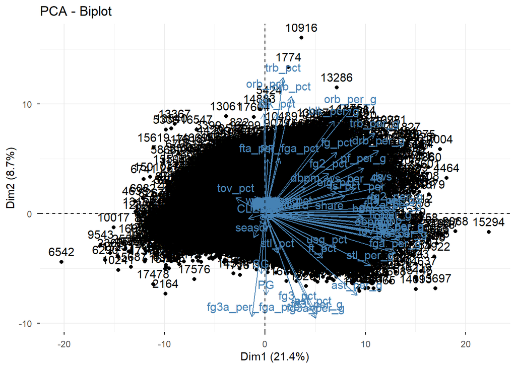

```r
fviz_pca_biplot(PCA_nba)
```

The individual PCA plots brings to the forefront another issue with the dataset. There are instances of players that played a very small number of games, where great numbers have been put up without the volume. Although a fitted model would take this into account, it is better to remove these players altogether as they are unnecessary to the model and would only increase training time with no real upside.

# Data cleaning 2

```r
# Filter to keep only players that have played at least 25 games
Data <- Data %>% filter(Data$g >= 25)
```

# EDA 2

## Correlations 2

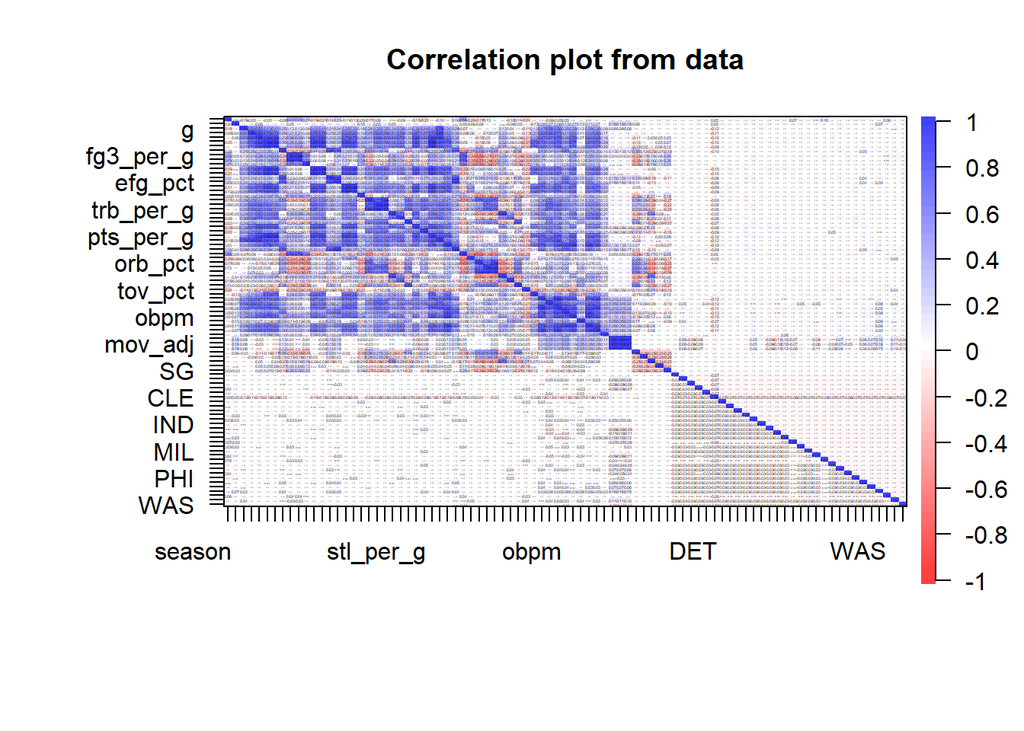

```r
#Correlations
cor_data <- cor(Data)
cor.plot(Data)
```

## PCA 2

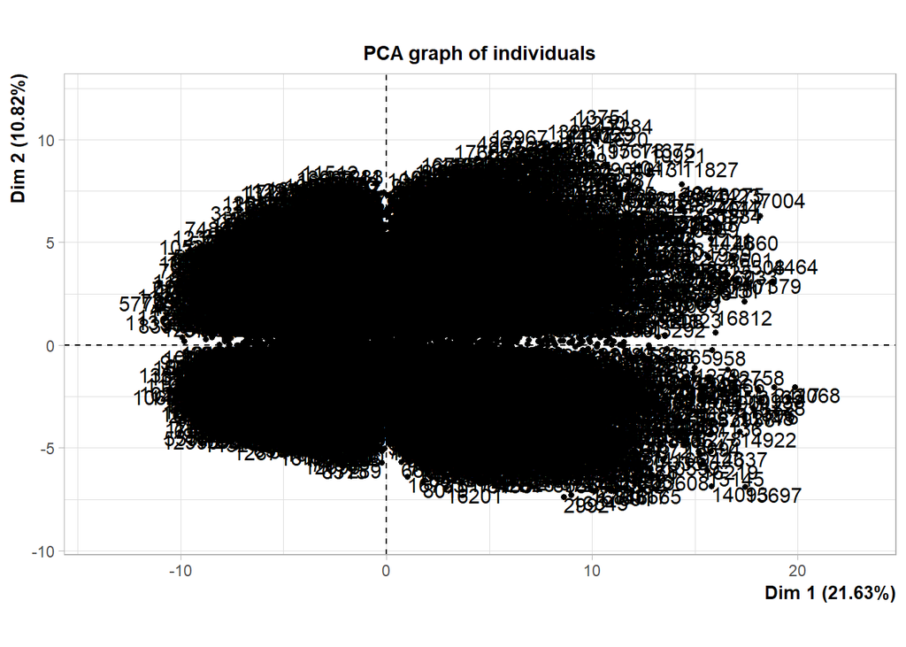

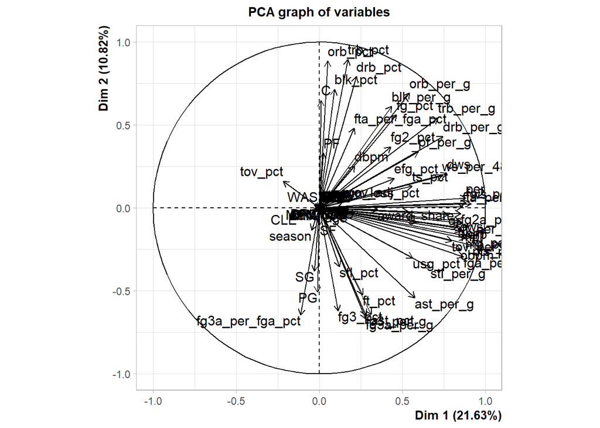

```r
#PCA for plots
PCA_nba <- PCA(Data, ncp = 14)
```

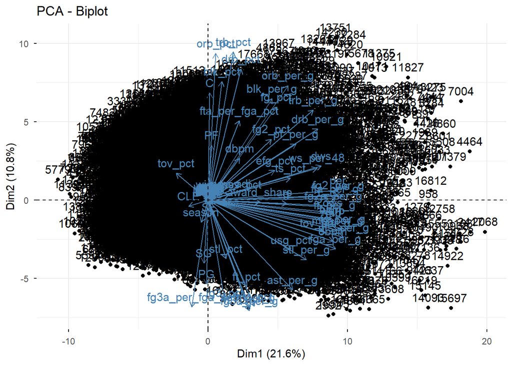

```r
fviz_pca_biplot(PCA_nba)
```

The first PC accounting for 21.6% of variation seems to describe the general performance quality while the second PC accounting for 10.8% of variation describes the size of the player.

```r
# PCA for loadings
pca_nba <- pca(Data, nfactors = 14)
pca_nba$loadings
```

```
Loadings:
                 RC1    RC2    RC5    RC6    RC3    RC8    RC4    RC7    RC9
season           -0.127  0.166  0.128  0.732                      -0.156
age                                           0.234         0.117  0.130
g                 0.477         0.163                              0.588
gs                0.761  0.130                                     0.405
mp_per_g          0.889                0.166                       0.326
fg_per_g          0.965
fga_per_g         0.957                0.157
fg_pct            0.229  0.341  0.804 -0.327
fg3_per_g         0.294 -0.305         0.827
fg3a_per_g        0.309 -0.310         0.831
fg3_pct           0.141 -0.432         0.563
fg2_per_g         0.933               -0.194
fg2a_per_g        0.940               -0.192
fg2_pct           0.179  0.241  0.846
efg_pct           0.188  0.127  0.903  0.220                       0.102
ft_per_g          0.913                                           -0.189
fta_per_g         0.905  0.116        -0.116                      -0.181
ft_pct            0.325 -0.470         0.226        -0.121
orb_per_g         0.441  0.687  0.137 -0.297               -0.101  0.149  0.193
drb_per_g         0.643  0.652                                     0.148  0.156
trb_per_g         0.608  0.699  0.113                              0.156  0.178
ast_per_g         0.633 -0.352         0.109         0.210  0.530
stl_per_g         0.675 -0.181                       0.572  0.146  0.165
blk_per_g         0.307  0.755                       0.122               -0.207
tov_per_g         0.872                      -0.111         0.279
pf_per_g          0.547  0.405        -0.167 -0.123                0.419
pts_per_g         0.972                0.132
mp                0.840                                            0.461
per               0.787  0.155  0.439                0.109        -0.269
ts_pct            0.324         0.891  0.136
fg3a_per_fga_pct -0.114 -0.358         0.851
fta_per_fga_pct   0.146  0.326  0.198 -0.454                      -0.274
orb_pct                  0.733  0.148 -0.440               -0.114         0.199
drb_pct                  0.892  0.107                                     0.209
trb_pct                  0.893  0.137 -0.202                              0.220
ast_pct           0.398 -0.485                       0.230  0.631 -0.108
stl_pct           0.120 -0.298                       0.819  0.159
blk_pct                  0.802  0.135                0.105               -0.248
```

[output cut: 131 more lines]

```
PHO                     -0.184
POR                                   -0.188  0.247
SAS                                          -0.352
TOR                                   -0.165
UTA                                           0.433
WAS                                          -0.146

                  RC1   RC2   RC5   RC6   RC3   RC8   RC4   RC7   RC9  RC10
SS loadings    17.198 7.751 4.715 4.281 3.758 2.422 2.276 1.945 1.488 1.328
Proportion Var  0.198 0.089 0.054 0.049 0.043 0.028 0.026 0.022 0.017 0.015
Cumulative Var  0.198 0.287 0.341 0.390 0.433 0.461 0.487 0.510 0.527 0.542
                RC11  RC12  RC14  RC13
SS loadings    1.171 1.163 1.157 1.127
Proportion Var 0.013 0.013 0.013 0.013
Cumulative Var 0.556 0.569 0.582 0.595
```

# Clustering

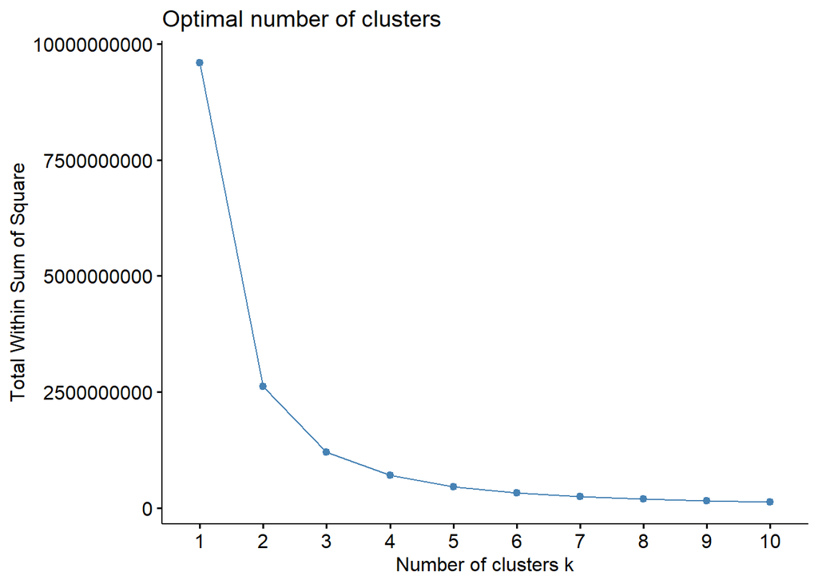

```r
Optnum_kmeans <- fviz_nbclust(Data, kmeans, method = "wss")
Optnum_kmeans
```

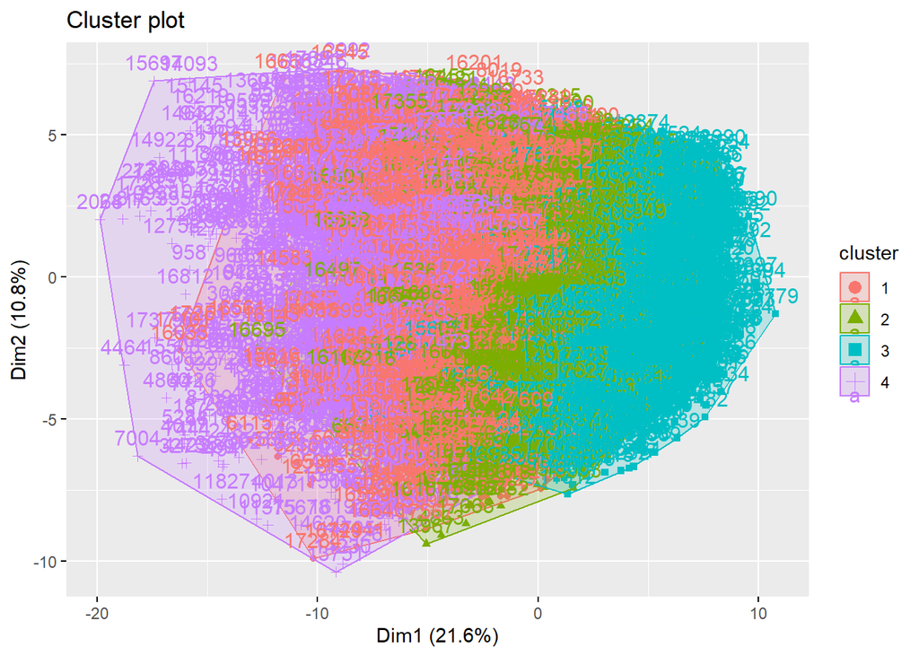

```r
Cluster_nba <- kmeans(Data, 4)

Cluster_plot <- fviz_cluster(Cluster_nba, data = Data, ellipse = TRUE, geom = c("point","text"))
Cluster_plot
```

# Linear Models

The team variable is removed, then to avoid multicollinearity issues, the following predictors are also removed:

- mp_per_g
- mp
- fg_per_g
- fga_per_g
- fg2_pct
- fg3a_per_g
- fg2a_per_g
- efg_pct
- ft_per_g
- fta_per_g
- orb_per_g
- drb_per_g
- ast_pct
- blk_pct
- obpm
- bpm
- orb_pct
- drb_pct
- ows
- dws
- vorp
- ws_per_48
- mov_adj
- mov
- C

## Normal regression (baseline)

```r
norm_model <- lm(award_share ~ season + age + g + gs + fg_pct + fg3_per_g + fg3_pct + fg2_per_g + ft_pct + trb_per_g + ast_per_g + stl_per_g + blk_per_g + tov_per_g + pf_per_g + pts_per_g + per + ts_pct + fg3a_per_fga_pct + fta_per_fga_pct + trb_pct + stl_pct + tov_pct + usg_pct + ws + dbpm + win_loss_pct + PF + PG + SF + SG, data = Data)

summary(norm_model)
```

```
Call:
lm(formula = award_share ~ season + age + g + gs + fg_pct + fg3_per_g +
    fg3_pct + fg2_per_g + ft_pct + trb_per_g + ast_per_g + stl_per_g +
    blk_per_g + tov_per_g + pf_per_g + pts_per_g + per + ts_pct +
    fg3a_per_fga_pct + fta_per_fga_pct + trb_pct + stl_pct +
    tov_pct + usg_pct + ws + dbpm + win_loss_pct + PF + PG +
    SF + SG, data = Data)

Residuals:
     Min       1Q   Median       3Q      Max
-0.16780 -0.01549  0.00046  0.01270  0.81782

Coefficients:
                    Estimate  Std. Error t value             Pr(>|t|)
(Intercept)       0.10128219  0.11175426   0.906              0.36480
season           -0.00001442  0.00005594  -0.258              0.79662
age              -0.00008107  0.00012509  -0.648              0.51693
g                -0.00046255  0.00003969 -11.654 < 0.0000000000000002 ***
gs               -0.00043247  0.00003112 -13.895 < 0.0000000000000002 ***
fg_pct            0.27788882  0.04769901   5.826   0.0000000058027335 ***
fg3_per_g        -0.02369294  0.00394561  -6.005   0.0000000019607854 ***
fg3_pct          -0.00806813  0.00386138  -2.089              0.03669 *
fg2_per_g        -0.01311516  0.00287572  -4.561   0.0000051417895179 ***
ft_pct            0.00426299  0.00801472   0.532              0.59481
trb_per_g        -0.00503446  0.00066371  -7.585   0.0000000000000352 ***
ast_per_g         0.00088689  0.00076837   1.154              0.24842
stl_per_g        -0.01988927  0.00357039  -5.571   0.0000000258386344 ***
blk_per_g         0.00384032  0.00171867   2.234              0.02547 *
tov_per_g         0.00779914  0.00279543   2.790              0.00528 **
pf_per_g         -0.00954886  0.00109593  -8.713 < 0.0000000000000002 ***
pts_per_g         0.00722805  0.00122185   5.916   0.0000000033808287 ***
per              -0.00228258  0.00049823  -4.581   0.0000046578418495 ***
ts_pct           -0.40226700  0.05335901  -7.539   0.0000000000000502 ***
fg3a_per_fga_pct  0.07082474  0.00921245   7.688   0.0000000000000159 ***
fta_per_fga_pct  -0.02250383  0.00703546  -3.199              0.00138 **
trb_pct           0.00228608  0.00037729   6.059   0.0000000014026878 ***
stl_pct           0.00336744  0.00200351   1.681              0.09283 .
tov_pct           0.00115906  0.00023567   4.918   0.0000008829983898 ***
usg_pct           0.00167320  0.00028291   5.914   0.0000000034100536 ***
ws                0.01696767  0.00051058  33.232 < 0.0000000000000002 ***
dbpm              0.00500064  0.00074222   6.737   0.0000000000167367 ***
win_loss_pct     -0.03499492  0.00421569  -8.301 < 0.0000000000000002 ***
PF                0.00092970  0.00165677   0.561              0.57470
PG               -0.00407587  0.00307873  -1.324              0.18556
SF                0.00125656  0.00218298   0.576              0.56488
SG                0.00140327  0.00256907   0.546              0.58493
---
Signif. codes:  0 '***' 0.001 '**' 0.01 '*' 0.05 '.' 0.1 ' ' 1

Residual standard error: 0.05634 on 14373 degrees of freedom
Multiple R-squared:  0.2644,    Adjusted R-squared:  0.2628
F-statistic: 166.7 on 31 and 14373 DF,  p-value: < 0.00000000000000022
```

The metrics are as follows:

```r
#Model metrics
norm_mse <- mse(Data$award_share, norm_model$fitted.values)
norm_aic <- AIC(norm_model)
norm_bic <- BIC(norm_model)
norm_Rsquared <- 1-((sum(norm_model$residuals^2))/(sum((Data$award_share-mean(Data$award_share))^2)))

norm_metrics <- as.table(cbind(norm_mse, norm_aic, norm_bic,norm_Rsquared))
colnames(norm_metrics) <- c("MSE","AIC","BIC","R-squared")
print(norm_metrics)
```

```
               MSE              AIC              BIC        R-squared
A      0.003167653 -41951.762657618 -41701.776746250      0.264418025
```

The R-squared is low so the normal linear model is not appropriate.

## Gamma regression

Response values of zero return undefined gamma variable values so a transformation is applied to the response to ensure it lies between 0 & 1 as follows:

```r
award_share_scaled01 <- scaleTR(Data$award_share, high = 1, low = 0, scale = 0.5)
summary(award_share_scaled01)
```

```
      Min.    1st Qu.     Median       Mean    3rd Qu.       Max.
0.00003471 0.00003471 0.00003471 0.00743218 0.00003471 0.99996529
```

The award share now strictly lies between zero and one

```r
gamma_model <- glm(award_share_scaled01 ~ season + age + g + gs + fg_pct + fg3_per_g + fg3_pct + fg2_per_g + ft_pct + trb_per_g + ast_per_g + stl_per_g + blk_per_g + tov_per_g + pf_per_g + pts_per_g + per + ts_pct + fg3a_per_fga_pct + fta_per_fga_pct + trb_pct + stl_pct + tov_pct + usg_pct + ws + dbpm + win_loss_pct + PF + PG + SF + SG, data = Data, family = Gamma(link = "inverse"))
summary(gamma_model)
```

```
Call:
glm(formula = award_share_scaled01 ~ season + age + g + gs +
    fg_pct + fg3_per_g + fg3_pct + fg2_per_g + ft_pct + trb_per_g +
    ast_per_g + stl_per_g + blk_per_g + tov_per_g + pf_per_g +
    pts_per_g + per + ts_pct + fg3a_per_fga_pct + fta_per_fga_pct +
    trb_pct + stl_pct + tov_pct + usg_pct + ws + dbpm + win_loss_pct +
    PF + PG + SF + SG, family = Gamma(link = "inverse"), data = Data)

Coefficients:
                    Estimate  Std. Error t value  Pr(>|t|)
(Intercept)       874.323596 4501.788319   0.194     0.846
season             -0.008288    2.251388  -0.004     0.997
age                -0.419533    5.214404  -0.080     0.936
g                 233.956657   55.165884   4.241 0.0000224 ***
gs               -234.503272   54.906901  -4.271 0.0000196 ***
fg_pct            592.343925 2141.010984   0.277     0.782
fg3_per_g        -101.488039  128.236295  -0.791     0.429
fg3_pct             7.318010   68.517960   0.107     0.915
fg2_per_g         -73.003312  102.868753  -0.710     0.478
ft_pct           -327.714336  432.672726  -0.757     0.449
trb_per_g         -21.632810   45.782853  -0.473     0.637
ast_per_g          -2.742785   13.897459  -0.197     0.844
stl_per_g         -51.886650  216.646758  -0.239     0.811
blk_per_g          -1.655858   44.474407  -0.037     0.970
tov_per_g           6.823906  107.827548   0.063     0.950
pf_per_g           -0.607202   32.207839  -0.019     0.985
pts_per_g          30.626082   42.616662   0.719     0.472
per                -4.900594   19.279112  -0.254     0.799
ts_pct           -424.901331 2739.234082  -0.155     0.877
fg3a_per_fga_pct  175.228578  466.362895   0.376     0.707
fta_per_fga_pct  -382.538534  442.380585  -0.865     0.387
trb_pct            14.919240   31.160292   0.479     0.632
stl_pct            30.617003  165.806995   0.185     0.854
tov_pct            -5.544170   29.179571  -0.190     0.849
usg_pct            -8.258983   18.567455  -0.445     0.656
ws                  1.917866   12.222310   0.157     0.875
dbpm                5.344016   19.892124   0.269     0.788
win_loss_pct     -146.496365  168.633302  -0.869     0.385
PF                 -8.086640   57.534052  -0.141     0.888
PG                 29.361193  143.026830   0.205     0.837
SF                 -5.531725  110.899738  -0.050     0.960
SG                 24.825154  116.662633   0.213     0.831
---
Signif. codes:  0 '***' 0.001 '**' 0.01 '*' 0.05 '.' 0.1 ' ' 1

(Dispersion parameter for Gamma family taken to be 558.0323)

    Null deviance: 145979  on 14404  degrees of freedom
Residual deviance:  54032  on 14373  degrees of freedom
AIC: -219746

Number of Fisher Scoring iterations: 22
```

```r
gamma_mse <- rmse(Data$award_share, gamma_model$fitted.values)
gamma_aic <- AIC(gamma_model)
gamma_bic <- BIC(gamma_model)
gamma_Rsquared <- 1-((sum(gamma_model$residuals^2))/(sum((Data$award_share-mean(Data$award_share))^2)))

gamma_metrics <- as.table(cbind(gamma_mse, gamma_aic, gamma_bic,gamma_Rsquared))
colnames(gamma_metrics) <- c("MSE","AIC","BIC","R-squared")
print(gamma_metrics)
```

```
                     MSE                    AIC                    BIC
A              0.1434323        -219746.0651125        -219496.0792011
               R-squared
A -2311157962321.3896484
```

## Beta regression

```r
#First you define the control
beta.control = betareg.control(phi = FALSE, hessian = TRUE, trace = TRUE)

beta_model <- betareg(award_share_scaled01 ~ season + age + g + gs + fg_pct + fg3_per_g + fg3_pct + fg2_per_g + ft_pct + trb_per_g + ast_per_g + stl_per_g + blk_per_g + tov_per_g + pf_per_g + pts_per_g + per + ts_pct + fg3a_per_fga_pct + fta_per_fga_pct + trb_pct + stl_pct + tov_pct + usg_pct + ws + dbpm + win_loss_pct + PF + PG + SF + SG, data = Data, dist = "beta", control = beta.control, link = "log")
print(beta_model)
```

```
Call:
betareg(formula = award_share_scaled01 ~ season + age + g + gs + fg_pct +
    fg3_per_g + fg3_pct + fg2_per_g + ft_pct + trb_per_g + ast_per_g +
    stl_per_g + blk_per_g + tov_per_g + pf_per_g + pts_per_g + per +
    ts_pct + fg3a_per_fga_pct + fta_per_fga_pct + trb_pct + stl_pct +
    tov_pct + usg_pct + ws + dbpm + win_loss_pct + PF + PG + SF + SG,
    data = Data, link = "log", dist = "beta", control = beta.control)

Coefficients (mean model with log link):
     (Intercept)            season               age                 g
      -2.2403457        -0.0007796        -0.0003107        -0.0045436
              gs            fg_pct         fg3_per_g           fg3_pct
      -0.0042479         2.4451846        -0.2415662        -0.0831607
       fg2_per_g            ft_pct         trb_per_g         ast_per_g
      -0.1056278        -0.0032682        -0.0549561         0.0106581
       stl_per_g         blk_per_g         tov_per_g          pf_per_g
      -0.1202721         0.0584161         0.0513490        -0.0934593
       pts_per_g               per            ts_pct  fg3a_per_fga_pct
       0.0685374        -0.0230539        -3.5822073         0.7553192
 fta_per_fga_pct           trb_pct           stl_pct           tov_pct
      -0.2085149         0.0246267         0.0270664         0.0120388
         usg_pct                ws              dbpm      win_loss_pct
       0.0158959         0.1559975         0.0392639        -0.2668605
              PF                PG                SF                SG
      -0.0041708        -0.0482472         0.0002248        -0.0084384
```

```r
beta_rmse <- rmse(Data$award_share, beta_model$fitted.values)
beta_aic <- AIC(beta_model)
beta_bic <- BIC(beta_model)
beta_Rsquared <- 1-((sum(beta_model$residuals^2))/(sum((Data$award_share-mean(Data$award_share))^2)))

beta_metrics <- as.table(cbind(beta_rmse, beta_aic, beta_bic,beta_Rsquared))
colnames(beta_metrics) <- c("MSE","AIC","BIC","R-squared")
round(beta_metrics,6)
```

```
            MSE           AIC           BIC     R-squared
A  6.054500e-02 -1.980561e+05 -1.978061e+05  1.489920e-01
```

## Generalised Additive Model

```r
GA_Model <- gamlss(award_share_scaled01 ~ season + pb(age) + pb(g) + gs + fg_pct + pb(fg3_per_g) + pb(fg3_pct) + fg2_per_g + pb(ft_pct) + pb(trb_per_g) + pb(ast_per_g) + pb(stl_per_g) + pb(blk_per_g) + pb(tov_per_g) + pb(pf_per_g) + pts_per_g + per + pb(ts_pct) + pb(fg3a_per_fga_pct) + fta_per_fga_pct + trb_pct + stl_pct + tov_pct + usg_pct + ws + pb(dbpm) + win_loss_pct + PF + PG + SF + SG, data = Data, family = BE())
```

```
GAMLSS-RS iteration 1: Global Deviance = -196417.1
GAMLSS-RS iteration 2: Global Deviance = -196773.9
GAMLSS-RS iteration 3: Global Deviance = -197093.2
GAMLSS-RS iteration 4: Global Deviance = -197377.1
GAMLSS-RS iteration 5: Global Deviance = -197627.9
GAMLSS-RS iteration 6: Global Deviance = -197847.9
GAMLSS-RS iteration 7: Global Deviance = -198039.4
GAMLSS-RS iteration 8: Global Deviance = -198204.6
GAMLSS-RS iteration 9: Global Deviance = -198346.3
GAMLSS-RS iteration 10: Global Deviance = -198466.9
GAMLSS-RS iteration 11: Global Deviance = -198569.1
GAMLSS-RS iteration 12: Global Deviance = -198655.1
GAMLSS-RS iteration 13: Global Deviance = -198726.9
GAMLSS-RS iteration 14: Global Deviance = -198795.8
GAMLSS-RS iteration 15: Global Deviance = -198846.1
GAMLSS-RS iteration 16: Global Deviance = -198887.6
GAMLSS-RS iteration 17: Global Deviance = -198921.7
GAMLSS-RS iteration 18: Global Deviance = -198949.6
GAMLSS-RS iteration 19: Global Deviance = -198972.5
GAMLSS-RS iteration 20: Global Deviance = -198991.2
```

```r
print(GA_Model)
```

```
Family:  c("BE", "Beta")
Fitting method: RS()

Call:  gamlss(formula = award_share_scaled01 ~ season + pb(age) +
    pb(g) + gs + fg_pct + pb(fg3_per_g) + pb(fg3_pct) +
    fg2_per_g + pb(ft_pct) + pb(trb_per_g) + pb(ast_per_g) +
    pb(stl_per_g) + pb(blk_per_g) + pb(tov_per_g) +
    pb(pf_per_g) + pts_per_g + per + pb(ts_pct) + pb(fg3a_per_fga_pct) +
    fta_per_fga_pct + trb_pct + stl_pct + tov_pct +
    usg_pct + ws + pb(dbpm) + win_loss_pct + PF + PG +
    SF + SG, family = BE(), data = Data)

Mu Coefficients:
         (Intercept)                season               pb(age)
          -3.0610476            -0.0003188            -0.0022872
               pb(g)                    gs                fg_pct
          -0.0057721            -0.0036183             1.1787211
       pb(fg3_per_g)           pb(fg3_pct)             fg2_per_g
          -0.0710632            -0.1219133             0.0601773
          pb(ft_pct)         pb(trb_per_g)         pb(ast_per_g)
          -0.0900176            -0.0296320            -0.0128011
       pb(stl_per_g)         pb(blk_per_g)         pb(tov_per_g)
          -0.0505221            -0.0088575            -0.2030093
        pb(pf_per_g)             pts_per_g                   per
          -0.0836845             0.0162161            -0.0101824
          pb(ts_pct)  pb(fg3a_per_fga_pct)       fta_per_fga_pct
          -3.3132331             0.7360587            -0.1396315
             trb_pct               stl_pct               tov_pct
           0.0010422            -0.0607418             0.0427987
             usg_pct                    ws              pb(dbpm)
           0.0289520             0.1986144             0.0651540
        win_loss_pct                    PF                    PG
          -0.3153680             0.0128706            -0.0745263
                  SF                    SG
           0.0113432            -0.0154738
Sigma Coefficients:
(Intercept)
    -0.9585

 Degrees of Freedom for the fit: 151.6 Residual Deg. of Freedom   14253
Global Deviance:     -198991
            AIC:     -198688
            SBC:     -197540
```

```r
GA_mse <- mse(Data$award_share, GA_Model$y)
GA_aic <- AIC(GA_Model)
GA_bic <- BIC(GA_Model)
GA_mae <- mae(Data$award_share, GA_Model$y)
GA_rmsle <- rmsle(Data$award_share, GA_Model$y)
GA_Rsquared <- 1-((sum(GA_Model$residuals^2))/(sum((Data$award_share-mean(Data$award_share))^2)))
GA_metrics <- as.table(cbind(GA_mse, GA_aic, GA_bic,GA_mae, GA_rmsle, GA_Rsquared))
colnames(GA_metrics) <- c("MSE","AIC","BIC","MAE","RMSLE","R-squared")
print(GA_metrics)
```

```
            MSE           AIC           BIC           MAE         RMSLE
A  1.190160e-09 -1.986880e+05 -1.975397e+05  3.441434e-05  3.444389e-05
      R-squared
A          -Inf
```

Despite the MSE being very close to zero, the r-squared is undefined. This is a sign of overfitting.

# Feature selection

This part will make use of random forest and lasso regression to determine the most insignificant features to be removed.

The first step is to scale the features, then split the dataset into the features and the response:

```r
#To split into the features and response

#scale the features

Data_scaled <- scale(Data)

#To split into the features and response

X <- (as.data.frame(Data_scaled)) %>% select(c("season", "age", "g", "gs", "fg_pct", "fg3_per_g", "fg3_pct", "fg2_per_g", "ft_pct", "trb_per_g", "ast_per_g", "stl_per_g", "blk_per_g", "tov_per_g", "pf_per_g", "pts_per_g", "per", "ts_pct", "fg3a_per_fga_pct", "fta_per_fga_pct", "trb_pct", "stl_pct", "tov_pct", "usg_pct", "ws", "dbpm", "win_loss_pct", "PF", "PG", "SF", "SG"))

Y <- Data$award_share
```

## Random Forest

```r
#rf model fitting
rf_model <- randomForest(x = X, y = Y, replace = TRUE, nodesize = 3, keep.inbag = TRUE, nPerm = 10 )

print(rf_model)
```

```
Call:
 randomForest(x = X, y = Y, replace = TRUE, nodesize = 3, nPerm = 10,      keep.inbag = TRUE)
               Type of random forest: regression
                     Number of trees: 500
No. of variables tried at each split: 10

          Mean of squared residuals: 0.001205569
                    % Var explained: 72
```

```r
#Metrics

rf_mae <- mae(Data$award_share, rf_model$predicted)

rf_rmse <- rmse(Data$award_share, rf_model$predicted)

rf_rmsle <- rmsle(Data$award_share, rf_model$predicted)

rf_Rsquared <- 1-((sum((Data$award_share-rf_model$predicted)^2))/(sum((Data$award_share-mean(Data$award_share))^2)))

rf_metrics <- as.table(cbind(rf_rmse, rf_mae, rf_rmsle, rf_Rsquared))
colnames(rf_metrics) <- c("RMSE","MAE","RMSLE","R-squared")

round(rf_metrics,6)
```

```
      RMSE      MAE    RMSLE R-squared
A 0.034721 0.005315 0.025887  0.720047
```

There is a big improvement for the R-squared compared to the linear models.

```r
# Extracting feature importance from the random forest

rf_importance <- as.data.frame(rf_model$importance)
rf_importance <-as.data.frame(cbind(as.data.frame(rownames(rf_importance)),rf_importance$IncNodePurity))
colnames(rf_importance) <- c("Feature","NodePurity")

rf_importance <- rf_importance %>% arrange(desc(NodePurity))
print(rf_importance)
```

```
            Feature  NodePurity
1                ws 18.21711953
2               per 11.72706623
3      win_loss_pct  4.84751533
4         pts_per_g  4.53726195
5           usg_pct  2.94292729
6         fg2_per_g  1.94366463
7              dbpm  1.83484085
8         tov_per_g  1.48358701
9         ast_per_g  1.46331371
10        trb_per_g  0.90658233
11           ts_pct  0.87855935
12               gs  0.85509345
13  fta_per_fga_pct  0.82766486
14                g  0.81417099
```

[output cut: 17 more lines]

The most useful predictors are the win shares, PER, win percentage and the pts per game. Usage, 2pt field goals per game, dbpm, assists per game and turnovers per game also all have node purities greater than one.

The least useful predictors are the position, defensive counting stats (blocks/steals per game) and age.

## Lasso Regression

```r
lasso_model <- glmnet(x = X, y = Y, alpha = 1)

print(lasso_model)
```

```
Call:  glmnet(x = X, y = Y, alpha = 1)

   Df  %Dev    Lambda
1   0  0.00 0.0262100
2   1  2.71 0.0238800
3   1  4.96 0.0217600
4   1  6.82 0.0198300
5   1  8.37 0.0180600
6   1  9.66 0.0164600
7   1 10.73 0.0150000
8   1 11.61 0.0136600
9   1 12.35 0.0124500
10  1 12.96 0.0113400
11  2 13.52 0.0103400
12  2 14.14 0.0094190
```

[output cut: 86 more lines]

```r
lasso_coeff <- coef(lasso_model, s = 0.0030840)

print(lasso_coeff)
```

```
32 x 1 sparse Matrix of class "dgCMatrix"
                    s=0.003084
(Intercept)       7.397987e-03
season            .
age               .
g                -3.971711e-03
gs               -2.568963e-03
fg_pct            .
fg3_per_g         .
fg3_pct           .
fg2_per_g         .
ft_pct           -1.138500e-09
trb_per_g         .
ast_per_g         .
stl_per_g         .
blk_per_g         .
tov_per_g         .
pf_per_g         -2.893654e-03
pts_per_g         .
per               .
ts_pct           -1.617384e-03
fg3a_per_fga_pct  .
fta_per_fga_pct   .
trb_pct           .
stl_pct           .
tov_pct           8.875812e-04
usg_pct           6.094287e-03
ws                2.670889e-02
dbpm              2.114395e-03
win_loss_pct      .
PF                .
PG                .
SF                .
SG                .
```

Here you can see the varying impacts of each predictor, by finding the lambda that minimises some loss function (like mse loss).

# Non-linear models

## Bagged CART model

```r
train_control <- trainControl(method = "cv", number = 10, savePredictions = "all", timingSamps = 1, returnResamp = "all")


CART_model <- train(X, Y, method = "treebag", metric = "RMSE", trControl = train_control, tuneLength = 3)

print(CART_model)
```

```
Bagged CART

14405 samples
   31 predictor

No pre-processing
Resampling: Cross-Validated (10 fold)
Summary of sample sizes: 12965, 12965, 12964, 12965, 12964, 12964, ...
Resampling results:

  RMSE        Rsquared   MAE
  0.03669043  0.6807102  0.005904535
```

## Parallel random forest

```r
# Parallel backend to run trees parallel instead of sequentially
num_cores <- parallel::detectCores() - 1

cl <- makeCluster(num_cores)
registerDoParallel(cl)

# Train control
train_control <- trainControl(method = "oob", savePredictions = "all", timingSamps = 1, returnResamp = "all")

# Model training
prf_model <- train(X, Y, method = "parRF", metric = "RMSE", trControl = train_control, tuneLength = 3)

#To stop cluster
stopCluster(cl)

print(prf_model)
```

```
Parallel Random Forest

14405 samples
   31 predictor

No pre-processing
Resampling results across tuning parameters:

  mtry  RMSE        Rsquared
   2    0.03819775  0.6611800
  16    0.03477684  0.7191504
  31    0.03520543  0.7121853

RMSE was used to select the optimal model using the smallest value.
The final value used for the model was mtry = 16.
```

# Model testing

This compares the random forest, parallel random forest, cart, beta regression and baseline regression.

```r
# Test dataset
NBA_test_dataset <- read_excel("C:/Users/Tsepo/Downloads/NBA_test_dataset.xlsx")


pre_scale_data <- (as.data.frame(Data)) %>% select(c("season", "age", "g", "gs", "fg_pct", "fg3_per_g", "fg3_pct", "fg2_per_g", "ft_pct", "trb_per_g", "ast_per_g", "stl_per_g", "blk_per_g", "tov_per_g", "pf_per_g", "pts_per_g", "per", "ts_pct", "fg3a_per_fga_pct", "fta_per_fga_pct", "trb_pct", "stl_pct", "tov_pct", "usg_pct", "ws", "dbpm", "win_loss_pct", "PF", "PG", "SF", "SG"))

complete_data <- rbind(pre_scale_data,NBA_test_dataset[,-c(1,33)])

complete_scaled <- scale(complete_data)

X_test <- complete_scaled[14406:14414,1:31]

Y_test <- NBA_test_dataset$award_share
```

## Normal regression

```r
#Normal regression test metrics

norm_predicts <- predict(norm_model,as.data.frame(X_test))

norm_mae <- mae(Y_test, norm_predicts)

norm_rmse <- rmse(Y_test, norm_predicts)

norm_rmsle <- rmsle(Y_test, norm_predicts)

norm_metrics <- as.table(cbind(norm_rmse, norm_mae, norm_rmsle))
colnames(norm_metrics) <- c("RMSE","MAE","RMSLE")

print(norm_metrics)
```

```
       RMSE       MAE     RMSLE
A 0.7959619 0.7198923 0.8815881
```

The normal regression, which had a training RMSE of close to zero, has produced a much ballooned RMSE this time around. The model was too simple and the assumptions of normality does not hold to the underlying structure of the data, so despite the good initial fit, the model was terrible when dealing with new data.

## Beta regression

```r
#Beta regression test metrics

beta_predicts <- predict(beta_model,as.data.frame(X_test))

beta_mae <- mae(Y_test, beta_predicts)

beta_rmse <- rmse(Y_test, beta_predicts)

beta_rmsle <- rmsle(Y_test, beta_predicts)

beta_metrics <- as.table(cbind(beta_rmse, beta_mae, beta_rmsle))
colnames(beta_metrics) <- c("RMSE","MAE","RMSLE")

print(beta_metrics)
```

```
       RMSE       MAE     RMSLE
A 0.4380176 0.2861607 0.3275465
```

The rmse is close to half that of the baseline, showing great improvement. However, the training rmse that was initially close to zero result in a greatly increased test rmse of 0.438, again a sign of a model that fails to comprehend the underlying structure of the data.

## Random forest

```r
# Random forest test metrics

rf_predicts <- predict(rf_model, X_test)

rf_mae <- mae(Y_test, rf_predicts)

rf_rmse <- rmse(Y_test, rf_predicts)

rf_rmsle <- rmsle(Y_test, rf_predicts)

rf_metrics <- as.table(cbind(rf_rmse, rf_mae, rf_rmsle))
colnames(rf_metrics) <- c("RMSE","MAE","RMSLE")

print(rf_metrics)
```

```
       RMSE       MAE     RMSLE
A 0.2173564 0.1772744 0.1497688
```

The random forest provides another improvement, reducing the test error by about 50% from the beta regression, and a 75% decrease from the baseline. This implies the data is non-linear. There is a relatively large increase from the training to the test rmse, a sign of overfitting.

## CART

```r
# CART model test metrics

cart_predicts <- predict(CART_model, X_test)

cart_mae <- mae(Y_test, cart_predicts)
cart_rmse <- rmse(Y_test, cart_predicts)
cart_rmsle <- rmsle(Y_test, cart_predicts)

cart_metrics <- as.table(cbind(cart_rmse, cart_mae, cart_rmsle))
colnames(cart_metrics) <- c("RMSE","MAE","RMSLE")

print(cart_metrics)
```

```
       RMSE       MAE     RMSLE
A 0.2403168 0.1745779 0.1629367
```

This model has slightly higher errors than the random forest, so that remains the best model.

## Parallel random forest

```r
# parallel random forest test metrics

prf_predicts <- predict(prf_model,X_test)

prf_mae <- mae(Y_test, prf_predicts)

prf_rmse <- rmse(Y_test, prf_predicts)

prf_rmsle <- rmsle(Y_test, prf_predicts)

prf_metrics <- as.table(cbind(prf_rmse, prf_mae, prf_rmsle))
colnames(prf_metrics) <- c("RMSE","MAE","RMSLE")

print(prf_metrics)
```

```
       RMSE       MAE     RMSLE
A 0.2095938 0.1683039 0.1435494
```